# Mid Project

#.Frequency of categorical features

```r
cate_column<-c("Gender","Parental_Involvement","Access_to_Resources","Extracurricular_Activities","Motivation_Level","Peer_Influence")
for(col in cate_column){
  print(paste("Frequency:",col))
  print(table(data[[col]]))
}
```

```
## [1] "Frequency: Gender"
##
## Female   Male
##   2793   3814
## [1] "Frequency: Parental_Involvement"
##
##   High    Low Medium
##   1908   1337   3362
## [1] "Frequency: Access_to_Resources"
##
##   High    Low Medium
##   1975   1313   3319
## [1] "Frequency: Extracurricular_Activities"
##
##   No  Yes
## 2669 3938
## [1] "Frequency: Motivation_Level"
##
##   High    Low Medium
##   1319   1937   3351
## [1] "Frequency: Peer_Influence"
##
## Negative  Neutral Positive
##     1377     2592     2638
```

#2. Bivariate Analysis

#.plot Heatmap

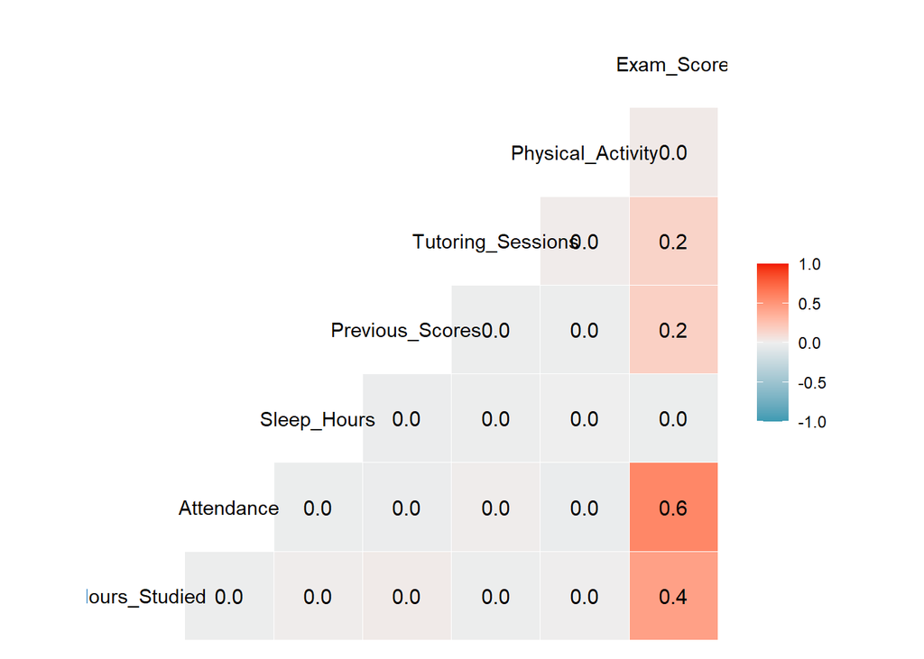

```r
ggcorr(data,label=TRUE)+
  theme(
    axis.text.x=element_text(angle=45,hjust=1)
  )
```

#.plot scatterplot matrix

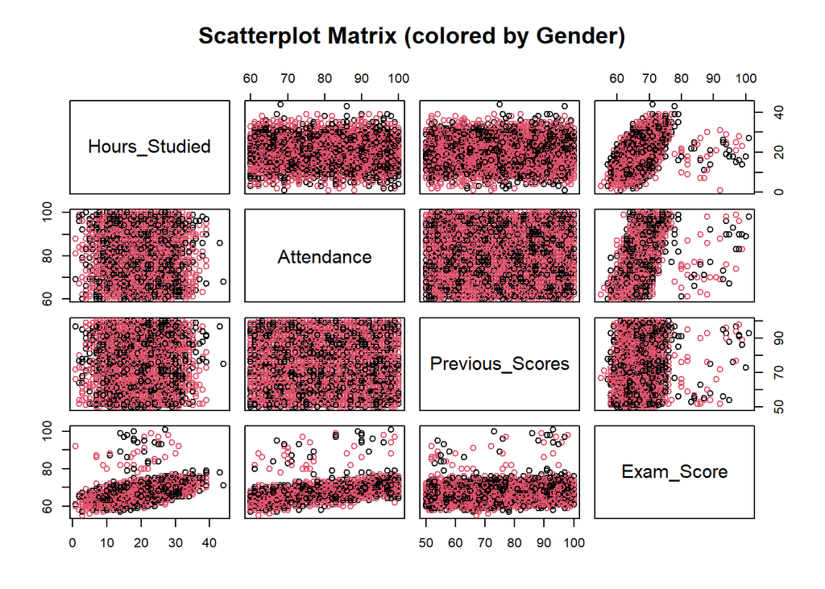

```r
pairs(data[,c("Hours_Studied","Attendance","Previous_Scores","Exam_Score")],main="Scatterplot Matrix (colored by Gender)",
      col=as.numeric(as.factor(data$Gender)))
```

#Boxplot between numeric and categorical

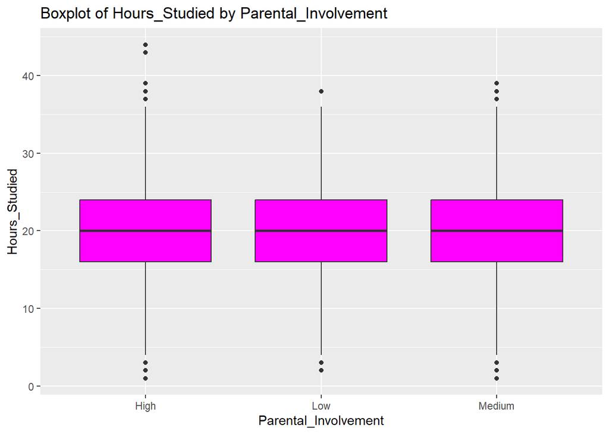

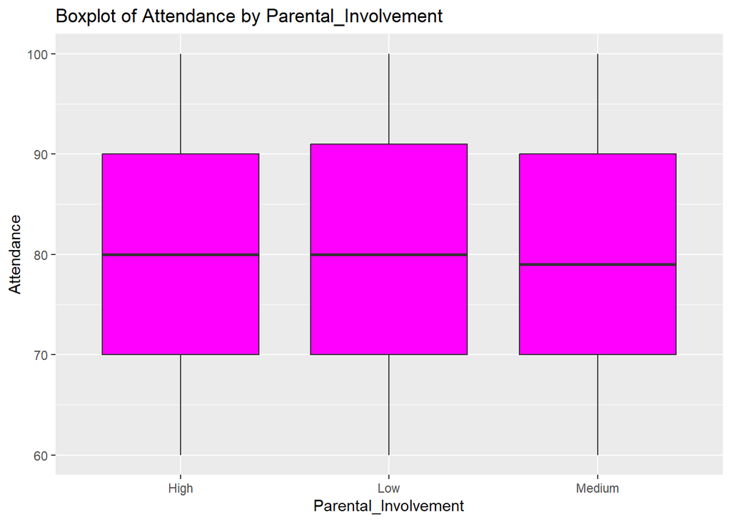

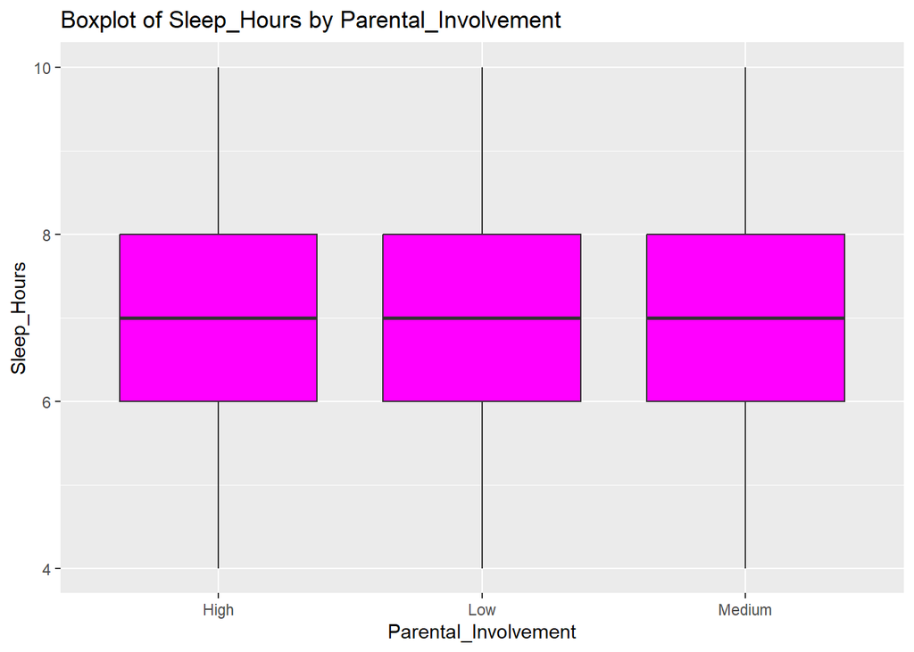

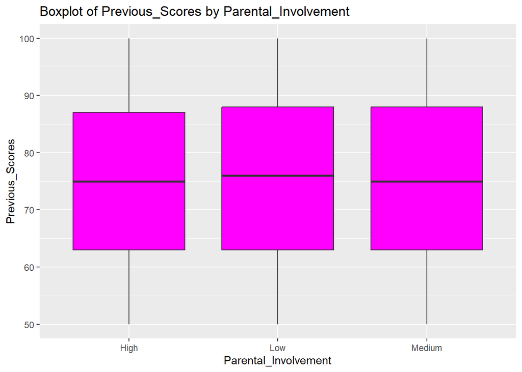

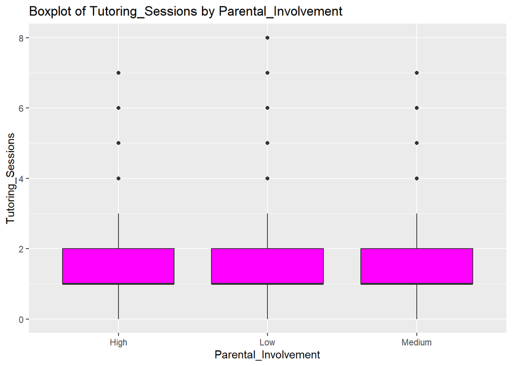

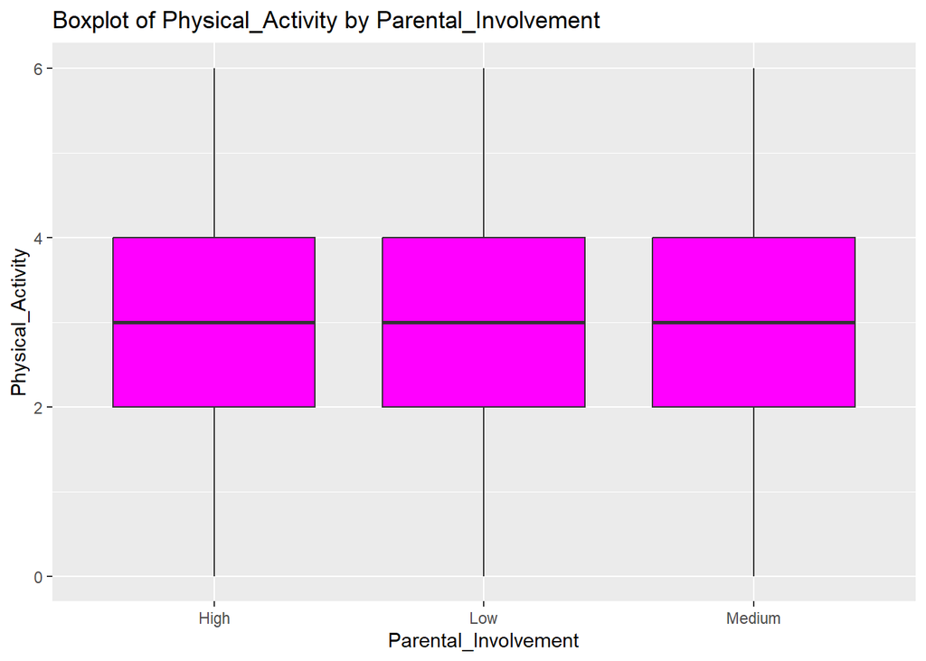

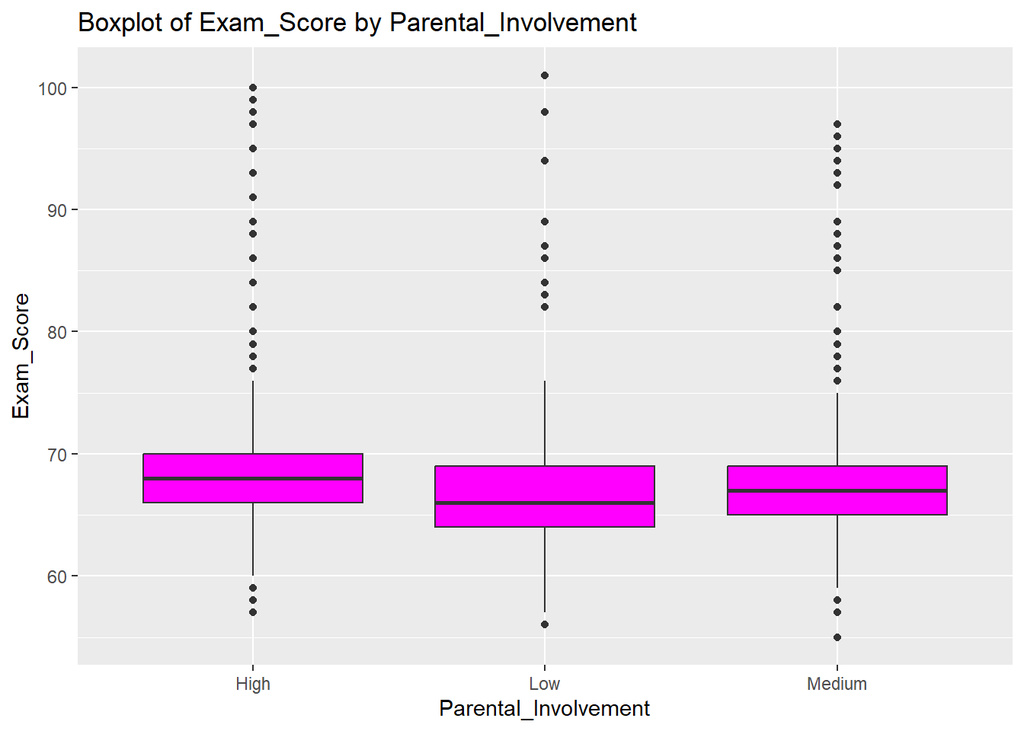

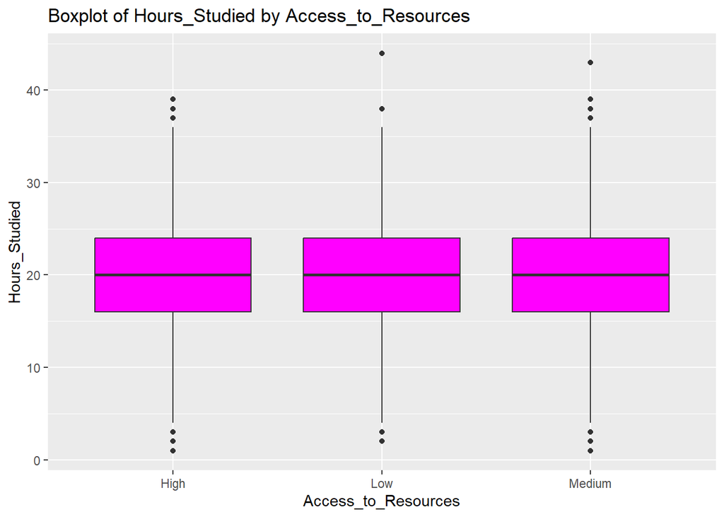

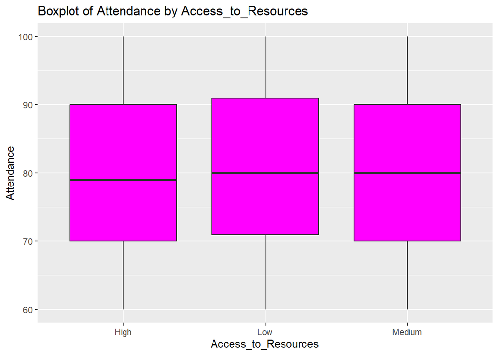

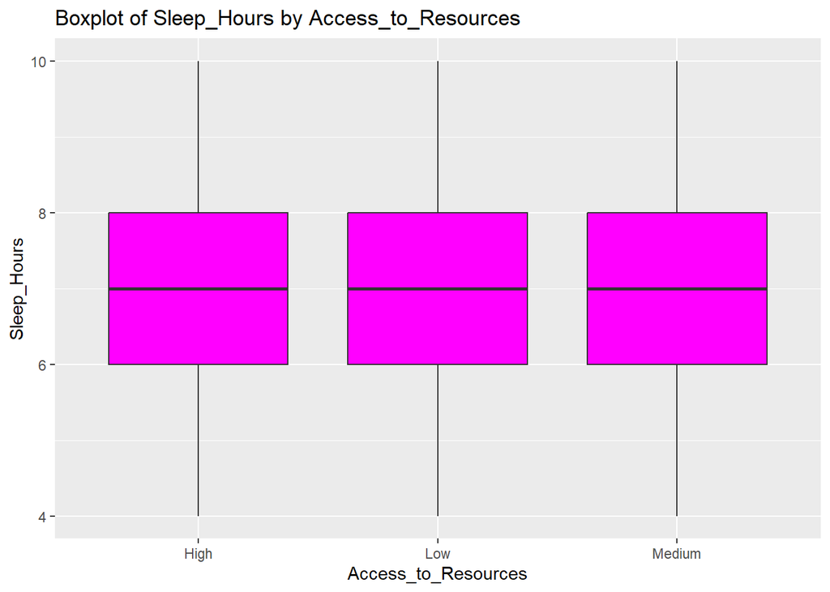

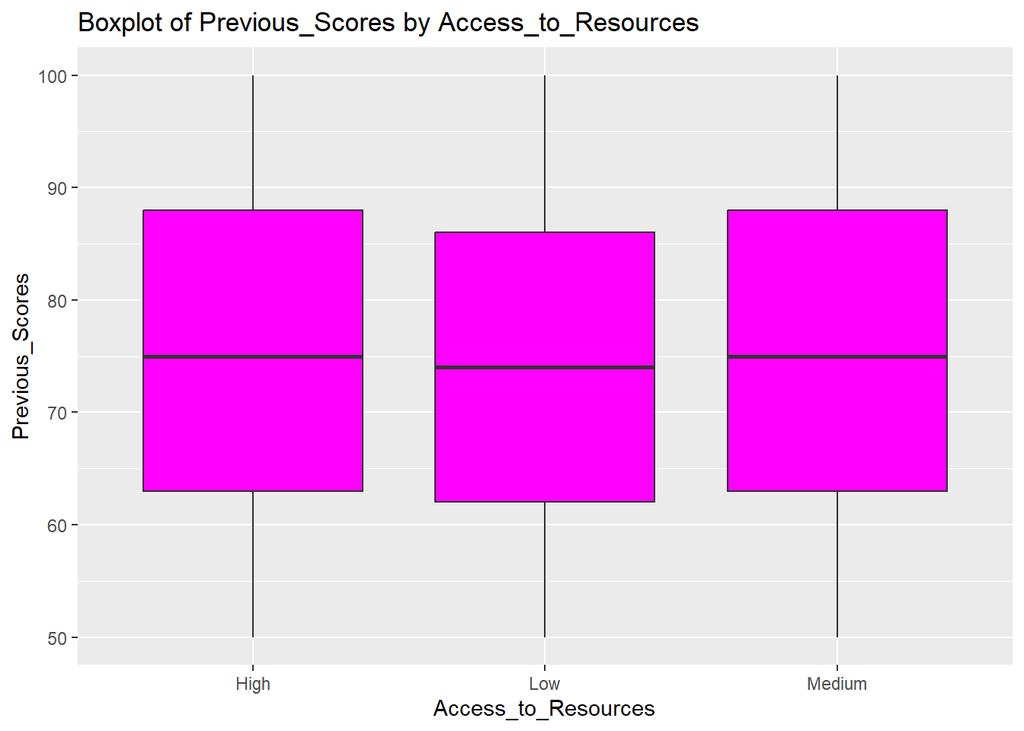

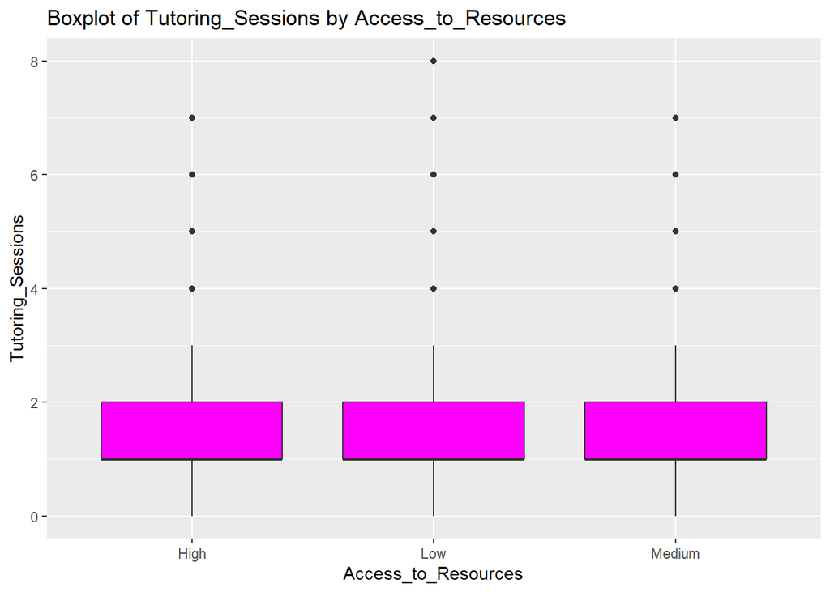

[79 more figures not shown]

```r
numerical_feature<-names(data)[sapply(data,is.numeric)]
categorical_feature<-names(data)[sapply(data,is.character)]
for(cat in categorical_feature){
  for(num in numerical_feature){
   p<-ggplot(data,aes_string(x=cat,y=num))+geom_boxplot(fill="MAGENTA")+labs(title=paste("Boxplot of",num,"by",cat),x=cat,y=num)
   print(p)
  }
}
```

#Skewness of Column

```r
numeric_cols<-c("Hours_Studied","Attendance","Previous_Scores","Exam_Score","Sleep_Hours")
sapply(data[numeric_cols],skewness,na.rm=TRUE)
```

```
##   Hours_Studied      Attendance Previous_Scores      Exam_Score     Sleep_Hours
##     0.013492780     0.013659655    -0.003734837     1.644061513    -0.023794629
```

#C.Data Preprocessing

#1.Handling Missing Values

```r
#Detect missing values
# Check how many NA values are in each column
colSums(is.na(data))
```

```
##              Hours_Studied                 Attendance
##                          0                          0
##       Parental_Involvement        Access_to_Resources
##                          0                          0
## Extracurricular_Activities                Sleep_Hours
##                          0                          0
##            Previous_Scores           Motivation_Level
##                          0                          0
##            Internet_Access          Tutoring_Sessions
##                          0                          0
##              Family_Income            Teacher_Quality
##                          0                          0
##                School_Type             Peer_Influence
##                          0                          0
##          Physical_Activity      Learning_Disabilities
##                          0                          0
##   Parental_Education_Level         Distance_from_Home
##                          0                          0
##                     Gender                 Exam_Score
##                          0                          0
```

#Remove NA columns

```r
data_clean<-na.omit(data)
```

# Verify that there are no more NA values

```r
cat("Total NA values after cleaning:",sum(is.na(data_clean)),"\n")
```

```
## Total NA values after cleaning: 0
```

# Remove Duplicate Rows

```r
data_clean<-data_clean[!duplicated(data_clean),]
```

# Filter students with Exam_Score>60

```r
data_filtered<-data_clean %>% filter(Exam_Score>60)
```

# Select specific columns of interest

```r
data_selected<-data_filtered %>% select(Exam_Score,Hours_Studied,Previous_Scores,Attendance)
```

# Create a new variable: Study Efficiency=Exam_Score per Hour Studied

```r
data_mutated<-data_selected %>%
  mutate(Study_Efficiency=Exam_Score/Hours_Studied)
```

#2.Handling Outliers

#Identify Outliers #box-plot with cleaned dataset

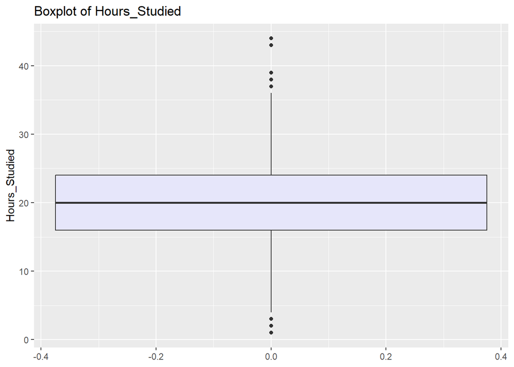

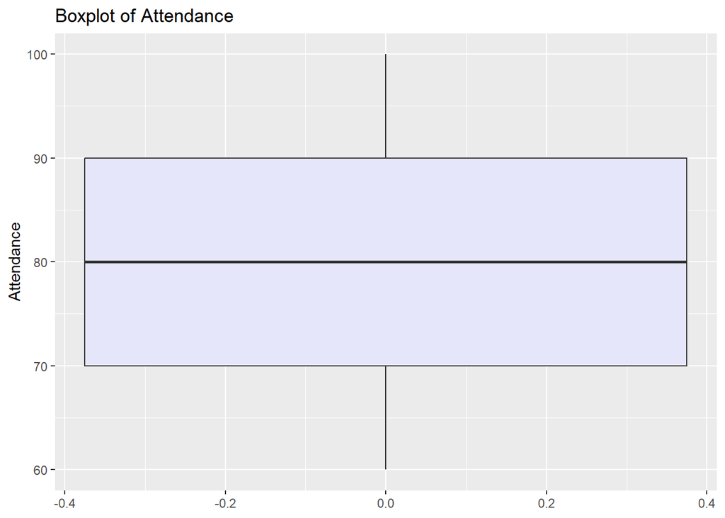

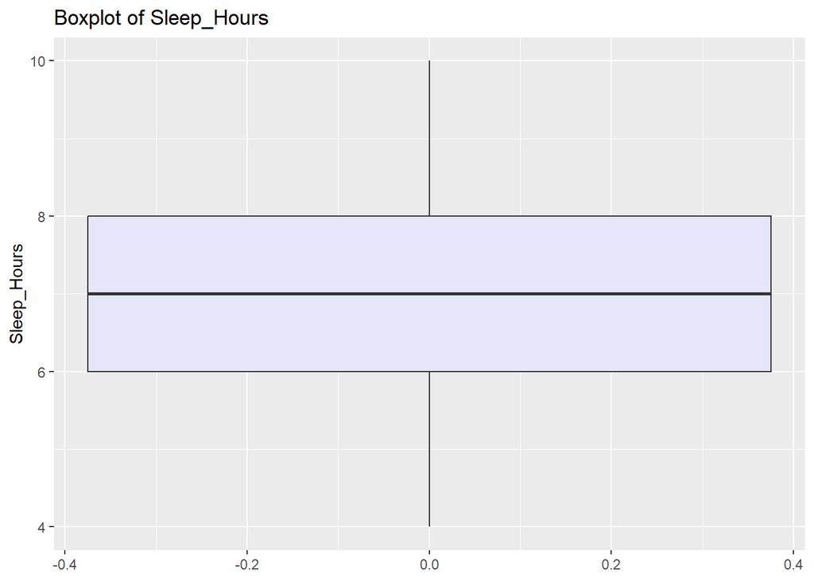

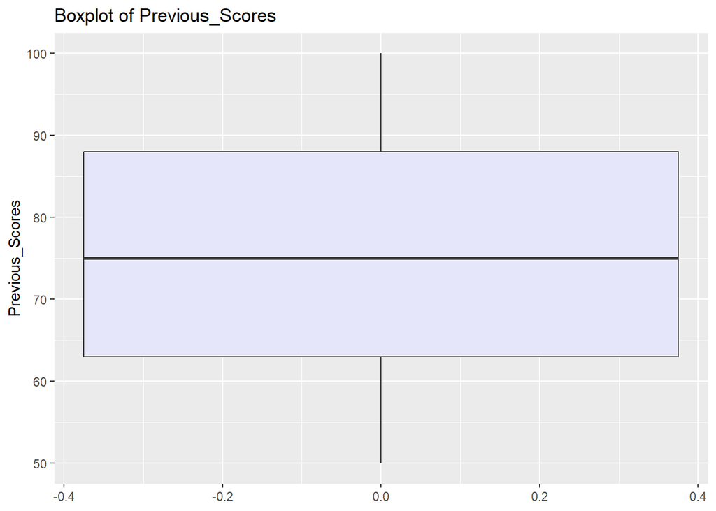

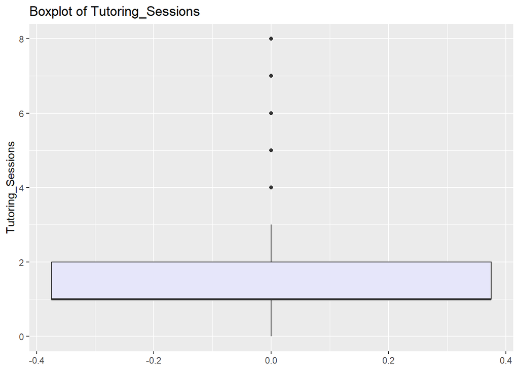

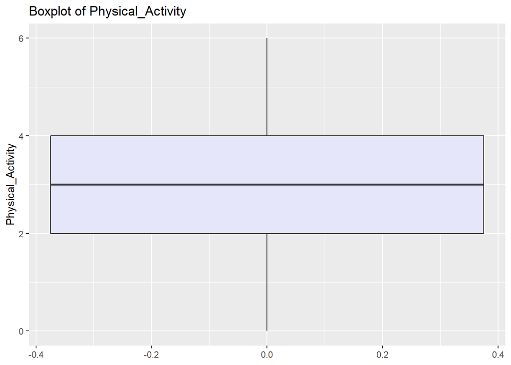

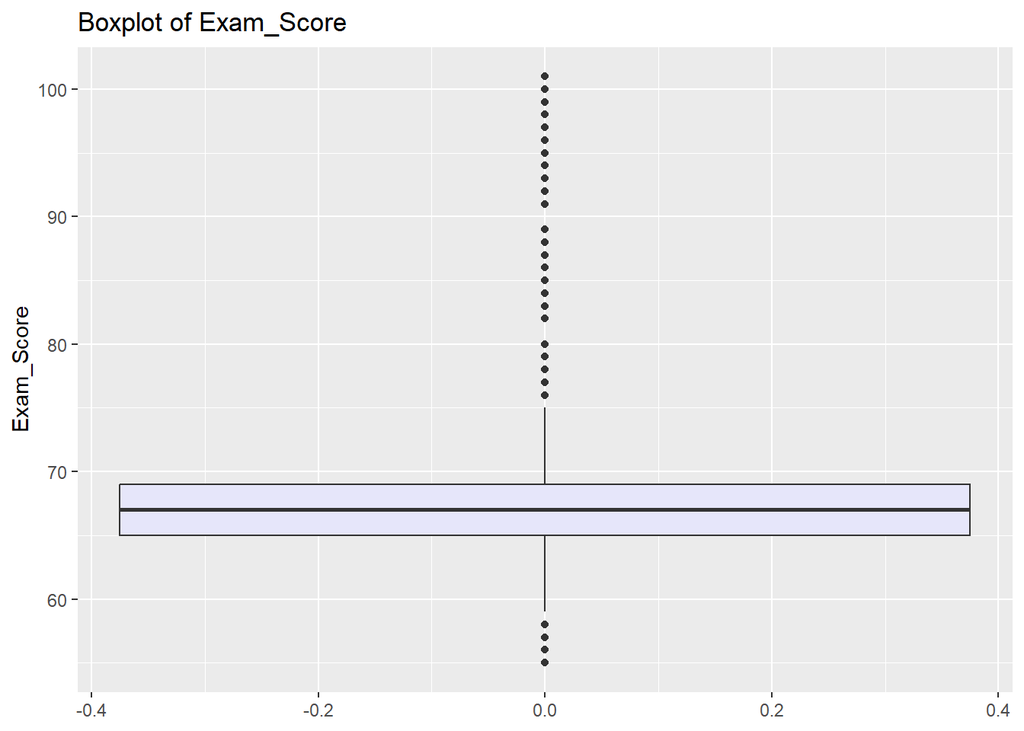

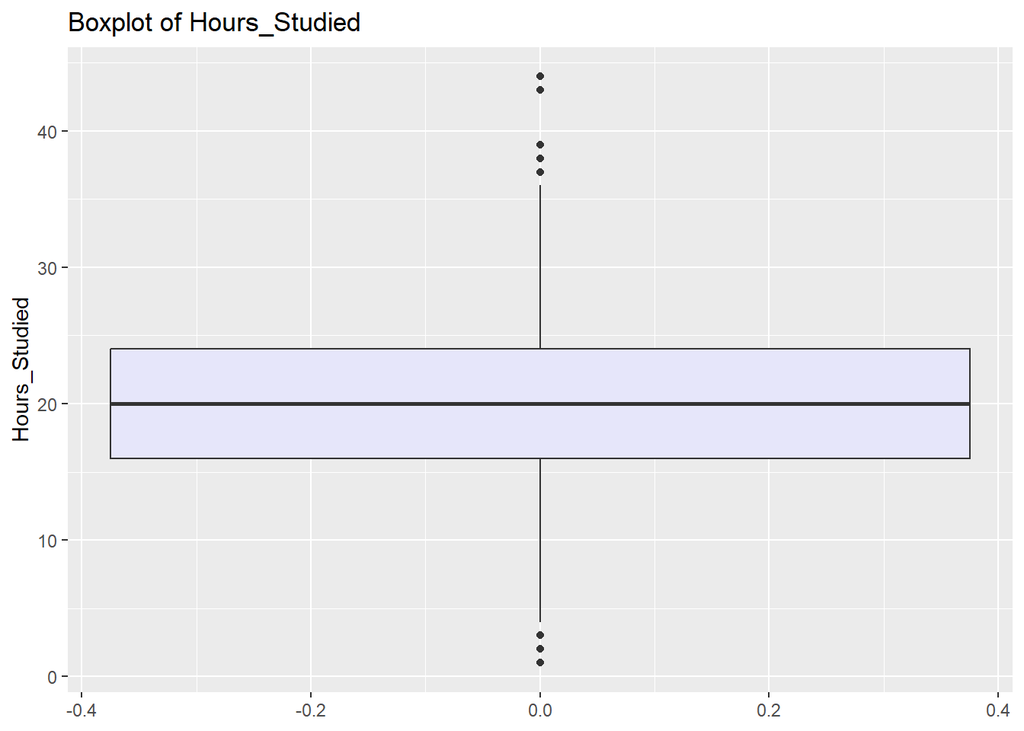

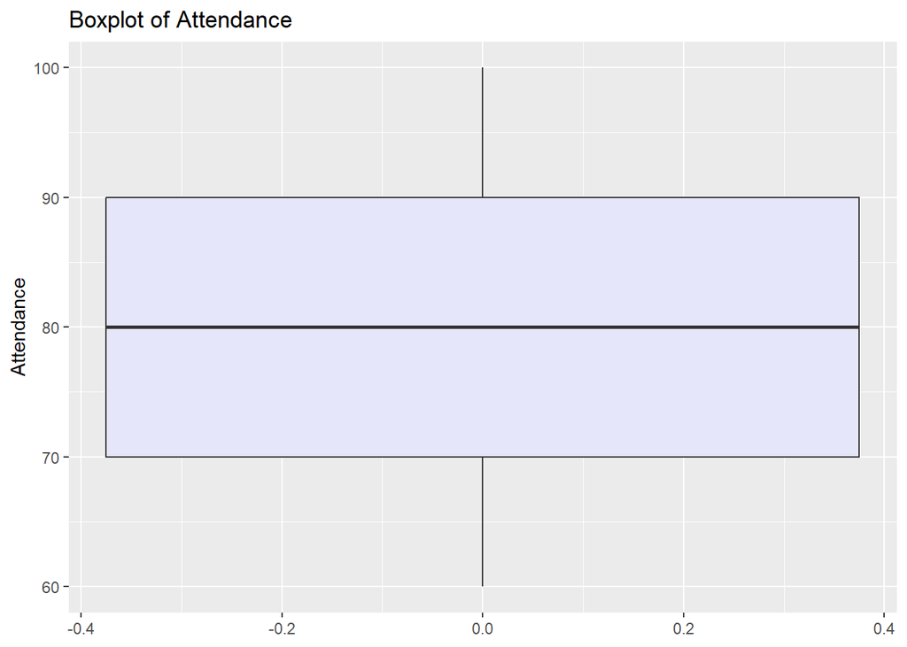

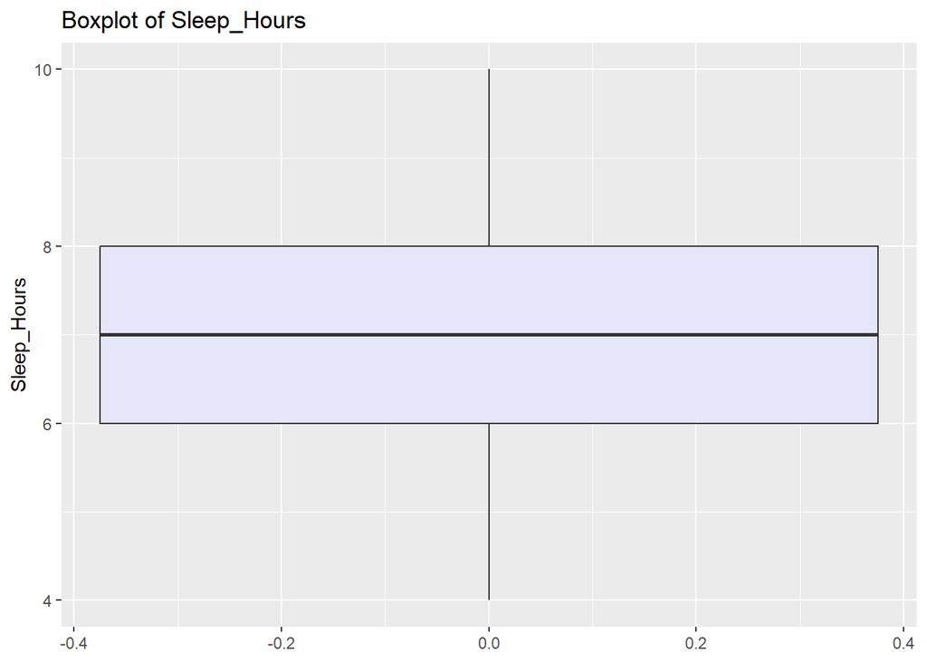

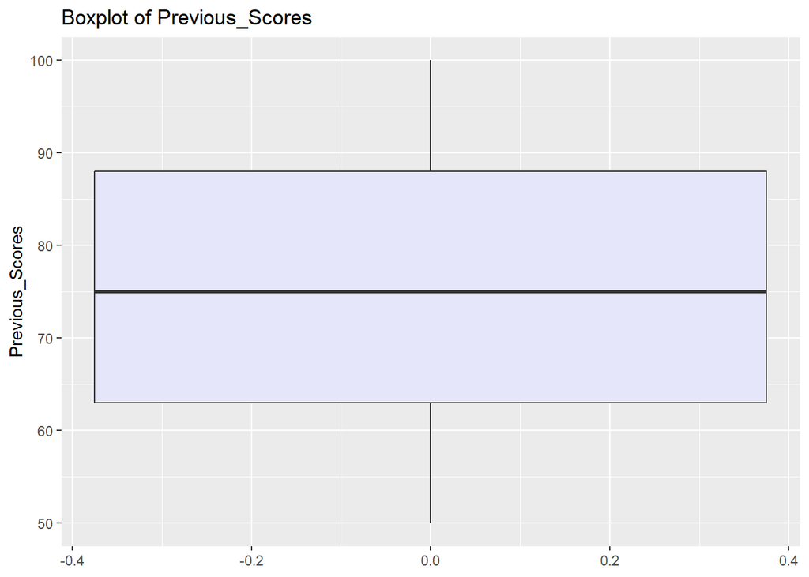

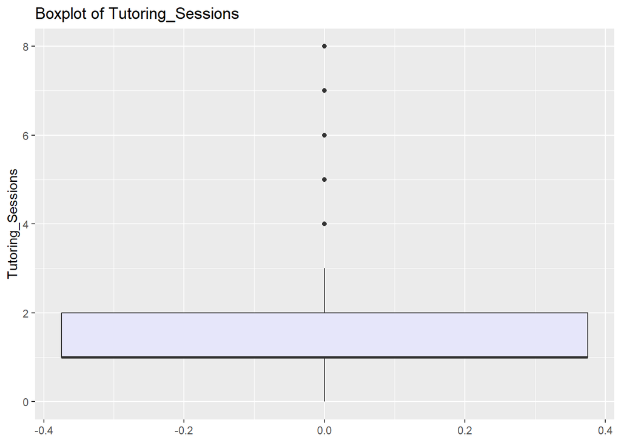

[2 more figures not shown]

```r
numeric_column<-names(data_clean)[sapply(data_clean,is.numeric)]
lapply(numeric_column,function(column){
  p<-ggplot(data_clean,aes_string(y=column))+geom_boxplot(fill="LAVENDER")+labs(title=paste("Boxplot of",column),y=column)
  print(p)
})
```

# Numeric columns outliers

```r
numeric_column<-names(data_clean)[sapply(data_clean,is.numeric)]
for(col in numeric_column){
  Q1<-quantile(data_clean[[col]],0.25)
  Q3<-quantile(data_clean[[col]],0.75)
  IQR_val<-Q3-Q1
  lower_bound<-Q1-1.5*IQR_val
  upper_bound<-Q3+1.5*IQR_val
  outliers<-data_clean[[col]][data_clean[[col]]<lower_bound | data_clean[[col]]>upper_bound]
  cat("Column:",col,"\n")
  cat("Number of outliers:",length(outliers),"\n")
  cat("Outliers:",if(length(outliers)<=10) outliers else "Too many to display","\n")
}
```

```
## Column: Hours_Studied
## Number of outliers: 43
## Outliers: Too many to display
## Column: Attendance
## Number of outliers: 0
## Outliers:
## Column: Sleep_Hours
## Number of outliers: 0
## Outliers:
## Column: Previous_Scores
## Number of outliers: 0
## Outliers:
## Column: Tutoring_Sessions
## Number of outliers: 430
## Outliers: Too many to display
## Column: Physical_Activity
## Number of outliers: 0
## Outliers:
## Column: Exam_Score
## Number of outliers: 104
## Outliers: Too many to display
```

#Use capping to remove outliers

```r
data_cap<-data_clean
numeric_columns<-names(data_cap)[sapply(data_cap,is.numeric)]
for(col in numeric_columns){
  Q1<-quantile(data_cap[[col]],0.25,na.rm=TRUE)
  Q3<-quantile(data_cap[[col]],0.75,na.rm=TRUE)
  IQR_val<-Q3-Q1
  lower_bound<-Q1-1.5*IQR_val
  upper_bound<-Q3+1.5*IQR_val
  data_cap[[col]]<-ifelse(data_cap[[col]]<lower_bound,lower_bound,ifelse(data_cap[[col]]>upper_bound,upper_bound,data_cap[[col]]))
}
```

#3. Data Conversion #Convert Categorical columns using one-hot coding

```r
categorical_columns<-names(data_clean)[sapply(data_clean,is.character)]
data_encoded<-fastDummies::dummy_cols(
  data_cap,select_col=categorical_columns,remove_first_dummy=TRUE,remove_selected_columns=TRUE
)
head(data_encoded)
```

```
##   Hours_Studied Attendance Sleep_Hours Previous_Scores Tutoring_Sessions
## 1            23         84           7              73                 0
## 2            19         64           8              59                 2
## 3            24         98           7              91                 2
## 4            29         89           8              98                 1
## 5            19         92           6              65                 3
## 6            19         88           8              89                 3
##   Physical_Activity Exam_Score Parental_Involvement_Low
## 1                 3         67                        1
## 2                 4         61                        1
## 3                 4         74                        0
## 4                 4         71                        1
## 5                 4         70                        0
## 6                 3         71                        0
##   Parental_Involvement_Medium Access_to_Resources_Low
```

[output cut: 62 more lines]

#Ensure all features are in a numeric form

```r
data_final_encoded<-data_encoded
data_final_encoded[]<-lapply(data_encoded,as.numeric)
str(data_final_encoded)
```

```
## 'data.frame':    6607 obs. of  31 variables:
##  $ Hours_Studied                        : num  23 19 24 29 19 19 29 25 17 23 ...
##  $ Attendance                           : num  84 64 98 89 92 88 84 78 94 98 ...
##  $ Sleep_Hours                          : num  7 8 7 8 6 8 7 6 6 8 ...
##  $ Previous_Scores                      : num  73 59 91 98 65 89 68 50 80 71 ...
##  $ Tutoring_Sessions                    : num  0 2 2 1 3 3 1 1 0 0 ...
##  $ Physical_Activity                    : num  3 4 4 4 4 3 2 2 1 5 ...
##  $ Exam_Score                           : num  67 61 74 71 70 71 67 66 69 72 ...
##  $ Parental_Involvement_Low             : num  1 1 0 1 0 0 0 1 0 0 ...
##  $ Parental_Involvement_Medium          : num  0 0 1 0 1 1 1 0 1 1 ...
##  $ Access_to_Resources_Low              : num  0 0 0 0 0 0 1 0 0 0 ...
##  $ Access_to_Resources_Medium           : num  0 1 1 1 1 1 0 0 0 1 ...
##  $ Extracurricular_Activities_Yes       : num  0 0 1 1 1 1 1 1 0 1 ...
##  $ Motivation_Level_Low                 : num  1 1 0 0 0 0 1 0 0 0 ...
##  $ Motivation_Level_Medium              : num  0 0 1 1 1 1 0 1 0 1 ...
```

[output cut: 17 more lines]

#4.Data Transformation #normalize and scalling using Z-score

```r
scale_cols<-data_mutated %>%select(where(is.numeric)) %>%names()
data_scaled<-data_mutated %>%
  mutate(across(all_of(scale_cols),~ scale(.)[,1]))
head(data_scaled)
```

```
##   Exam_Score Hours_Studied Previous_Scores Attendance Study_Efficiency
## 1 -0.1107117     0.4823309      -0.1550155  0.3223564     -0.386320701
## 2 -1.7141904    -0.1977896      -1.1277523 -1.4285615     -0.248081059
## 3  1.7600136     0.6523611       1.0956460  1.5479990     -0.307187368
## 4  0.9582742     1.5025118       1.5820143  0.7600859     -0.602297223
## 5  0.6910277    -0.1977896      -0.7108651  1.0227236     -0.027961015
## 6  0.9582742    -0.1977896       0.9566836  0.6725400     -0.003503232
```

#normalize and scalling using min_max

```r
data_minmax<-data_mutated %>%
  mutate(across(all_of(scale_cols),~(.-min(.))/(max(.)-min(.))))
head(data_minmax)
```

```
##   Exam_Score Hours_Studied Previous_Scores Attendance Study_Efficiency
## 1      0.150     0.5116279            0.46      0.600      0.014376141
## 2      0.000     0.4186047            0.18      0.100      0.017667377
## 3      0.325     0.5348837            0.82      0.950      0.016260163
## 4      0.250     0.6511628            0.96      0.725      0.009234131
## 5      0.225     0.4186047            0.30      0.800      0.022908037
## 6      0.250     0.4186047            0.78      0.700      0.023490333
```

#Apply log/sqrt transformation

```r
numeric_cols<-names(data_mutated)[sapply(data_mutated,is.numeric)]
data_transformed<-data_mutated
for(col in numeric_cols){
  sk<-skewness(data_mutated[[col]])
  if(sk>1){
    data_transformed[[paste0(col,"_log")]]<-log(data_mutated[[col]]+1)

  } else if(sk>0.5){
    data_transformed[[paste0(col,"_sqrt")]]<-sqrt(data_mutated[[col]])
  }
}
```

#5.Feature Selection #Identify and retain the most important features. #Correlated Feature Identify

```r
numeric_cols<-names(data_transformed)[sapply(data_transformed,is.numeric)]
cor_matrix<-cor(data_transformed[,numeric_cols],use="complete.obs")
for(col in numeric_cols){
  cor_list<-sort(abs(cor_matrix[col,]),decreasing=TRUE)
  cor_list_sorted<-cor_list[names(cor_list)!=col]
  cat("Column:",col,"\n")
  cat("Important feature:",names(cor_list_sorted)[1],"with correlation=",round(cor_list_sorted[1],3),"\n")
}
```

```
## Column: Exam_Score
## Important feature: Exam_Score_log with correlation= 0.997
## Column: Hours_Studied
## Important feature: Study_Efficiency_log with correlation= 0.922
## Column: Previous_Scores
## Important feature: Exam_Score_log with correlation= 0.167
## Column: Attendance
## Important feature: Exam_Score_log with correlation= 0.582
## Column: Study_Efficiency
## Important feature: Study_Efficiency_log with correlation= 0.838
## Column: Exam_Score_log
## Important feature: Exam_Score with correlation= 0.997
## Column: Study_Efficiency_log
## Important feature: Hours_Studied with correlation= 0.922
```

#plot correlation matrix

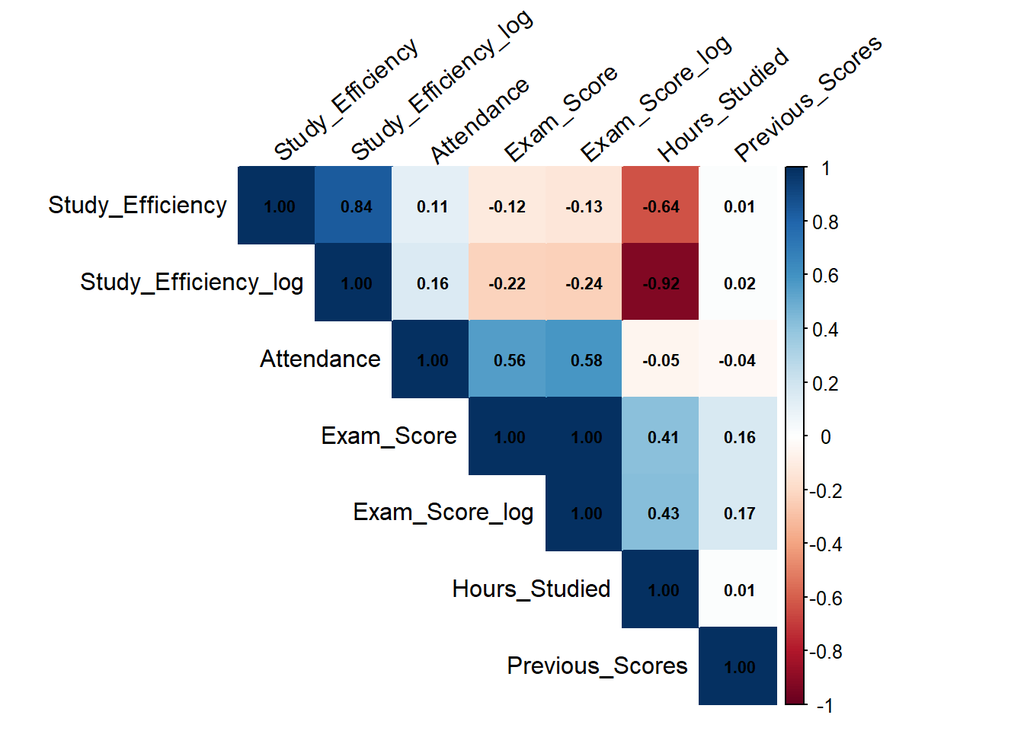

```r
corrplot(cor_matrix, method="color",type="upper",
         order="hclust",
         addCoef.col="black",
         tl.col="black",tl.srt=40,
         number.cex=0.7)
```

#Use correlation analysis,variance thresholding and mutual information #Variance thresholding

```r
var_values<-sapply(data_transformed[,numeric_cols],var)
selected_features_var<-names(var_values[var_values>0.01])
print(selected_features_var)
```

```
## [1] "Exam_Score"           "Hours_Studied"        "Previous_Scores"
## [4] "Attendance"           "Study_Efficiency"     "Study_Efficiency_log"
```

#Mutual Information # Compute MI for all numeric features with target Exam_Score

```r
numeric_cols<-names(data_transformed)[sapply(data_transformed,is.numeric)]
mi_scores<-information_gain(Exam_Score ~ .,data=data_transformed[,c(numeric_cols,"Exam_Score")])
mi_selected<-mi_scores$attributes[mi_scores$importance>0]
print(mi_selected)
```

```
## [1] "Hours_Studied"        "Previous_Scores"      "Attendance"
## [4] "Study_Efficiency"     "Exam_Score_log"       "Study_Efficiency_log"
## [7] "Exam_Score.1"
```

# Compute MI for all numeric features with target Previous_Score

```r
numeric_cols<-names(data_transformed)[sapply(data_transformed,is.numeric)]
mi_scores<-information_gain(Previous_Scores~ .,data=data_transformed[,c(numeric_cols,"Previous_Scores")])
mi_selected<-mi_scores$attributes[mi_scores$importance>0]
print(mi_selected)
```

```
## [1] "Previous_Scores.1"
```

# Compute MI for all numeric features with target Hours_Studied

```r
numeric_cols<-names(data_transformed)[sapply(data_transformed,is.numeric)]
mi_scores<-information_gain(Hours_Studied ~ .,data=data_transformed[,c(numeric_cols,"Hours_Studied")])
mi_selected<-mi_scores$attributes[mi_scores$importance>0]
print(mi_selected)
```

```
## [1] "Exam_Score"           "Study_Efficiency"     "Exam_Score_log"
## [4] "Study_Efficiency_log" "Hours_Studied.1"
```

# Compute MI for all numeric features with target Attendance

```r
numeric_cols<-names(data_transformed)[sapply(data_transformed,is.numeric)]
mi_scores<-information_gain(Attendance ~ .,data=data_transformed[,c(numeric_cols,"Attendance")])
mi_selected<-mi_scores$attributes[mi_scores$importance>0]
print(mi_selected)
```

```
## [1] "Exam_Score"     "Exam_Score_log" "Attendance.1"
```